# ABO WGS - 1000 Genomes 30x on GRCH38

Jonathan Stevens

## 1000 Genomes 30x on GRCH38

1000 Genomes 30x on GRCH38 (Byrska-Bishop et al. 2021) data set was obtained from https://www.internationalgenome.org/data-portal/data-collection/30x-grch38. The cram files were downloaded and filtered for the ABO gene using samtools (Li et al. 2009) view and coordinates chr9:133255176-133385146.

```bash
# example usage of samtools view command
samtools view -h -C -T ../ref/Homo_sapiens_assembly38.fasta     ftp://ftp.sra.ebi.ac.uk/vol1/run/ERR323/ERR3239484/NA12778.final.cram    chr9:133255176-133385146 >     NA12778.extract_for_bloodantigens-full_gene_master.cram
```

### 1.1 ABO gene sequence depth

depth.sh was used to iterate over all cram files in the directory, process with samtools depth, and output depth file per sample.

```bash
# example usage of samtools depth command for one sample cram
# -a (all positions), -r (specified region)
samtools depth -a -r chr9:133255176-133385146 /Users/jonathan_stevens/ABO/1000G_data/cram/HG00096.extract_for_bloodantigens-full_gene_master.cram -o /Users/jonathan_stevens/ABO/1000G_data/depth/HG00096_ABO_pos_read_depth_of_coverage.txt
```

The depth command creates a tab separated file (sample_ABO_pos_read_depth_of_coverage.txt) containing chromosome, position, and depth:

```
## chr9 133255176   94
## chr9 133255177   96
## chr9 133255178   96
## chr9 133255179   95
## chr9 133255180   96
## ...
```

#### 1.1.1 Average depth per 100 base interval

coverage_per_interval_ABO.py was used to iterate over the depth files in a directory and write the average sequence depth of each sample per 100 base interval to a tab delimited text file (1000G_100bp_avg_read_depth_of_coverage.txt).

### 1.2 ABO gene sequence copy number

copy_number_per_interval.py was used to iterate over depth files in a directory and write the average copy number of each sample per 100 base interval to a tab delimited text file (1000G_100bp_avg_copy_number.txt). The text file was formatted in Excel with conditional highlighting to visualize copy number (1000G_100bp_avg_copy_number.xlsx).

copy_number_per_region.py - iterate over depth files in a directory and write the average copy number gene region (UTRs, exons, introns) to a tab delimited text file (copy_number_per_region.txt). The text file was formatted in Excel with conditional highlighting to visualize copy number (copy_number_per_region.xlsx).

copy_number_per_region.xlsx sorted for large ABO deletion (Highlighted sample names found in paper):

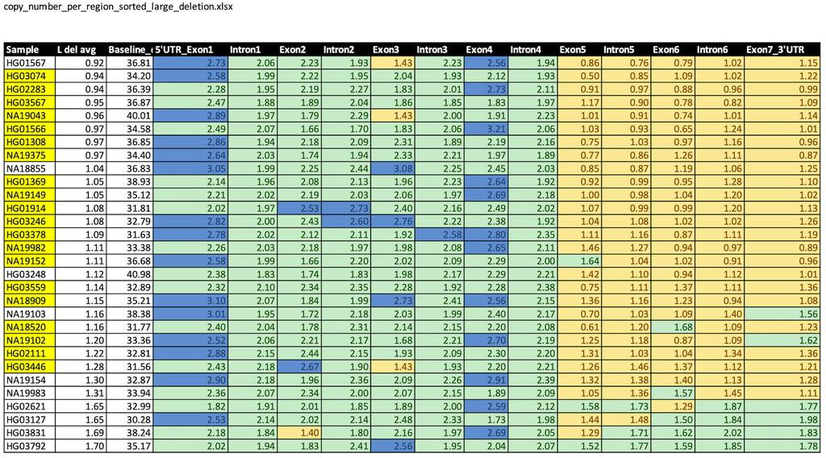

IGV visualization of large deletion for HG02111:

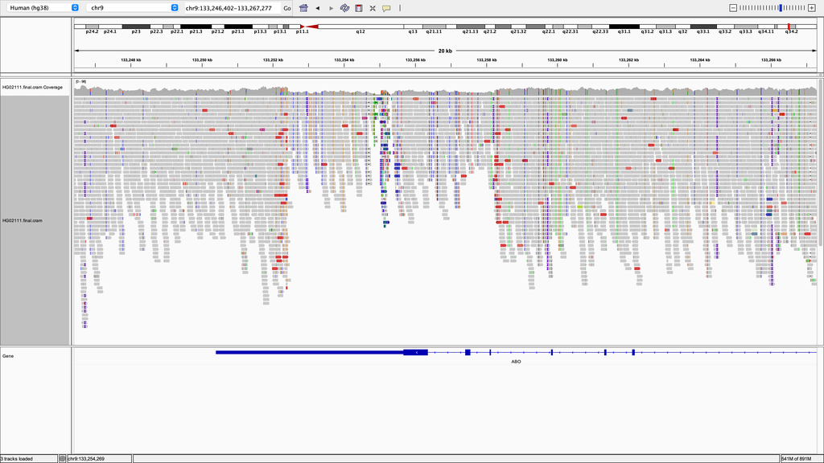

## 2. VCF Analysis

### 2.1 Genotype VCF (nonphased) analysis

The nonphased chromosome 9 VCF file and index were obtained from https://www.internationalgenome.org/data-portal/data-collection/30x-grch38.

```bash
curl -C - -O ftp://ftp.1000genomes.ebi.ac.uk/vol1/ftp/data_collections/1000G_2504_high_coverage/working/20201028_3202_raw_GT_with_annot/20201028_CCDG_14151_B01_GRM_WGS_2020-08-05_chr9.recalibrated_variants.vcf.gz

curl -C - -O ftp://ftp.1000genomes.ebi.ac.uk/vol1/ftp/data_collections/1000G_2504_high_coverage/working/20201028_3202_raw_GT_with_annot/20201028_CCDG_14151_B01_GRM_WGS_2020-08-05_chr9.recalibrated_variants.vcf.gz.tbi
```

vcftools (P. Danecek et al. 2011) was used to extract the ABO gene using coordinates 133246000-133320000 and write to a new VCF.

```bash
vcftools --gzvcf 20201028_CCDG_14151_B01_GRM_WGS_2020-08-05_chr9.recalibrated_variants.vcf.gz --out chr9_ABO.recalibrated_variants --chr chr9 --from-bp 133246000 --to-bp 133320000 --recode
```

#### 2.1.1 Full sequence variants

bcftools (Petr Danecek et al. 2021) query was used to create a tab separated file containing the variant genotype calls translated to IUPAC codes.

```bash
bcftools query -f '%POS[\t%IUPACGT]\n' -H -o ABO_vcf_table.txt chr9_ABO.recalibrated.variants.recode.vcf
```

transpose_table.py was used to read ABO_vcf_table.txt as a pandas dataframe, transpose the dataframe, and write the dataframe to a new text file, ABO_vcf_table_transposed.txt

reverse_complement.py was used to reverse complement the data in ABO_vcf_table_transposed.txt and write to a new file, ABO_vcf_table_transposed_reverse_complement.txt.

#### 2.1.2 CDS variants

bcftools query was used to create a tab separated file containing the variant genotype calls translated to IUPAC codes for the coding sequence. The -R (–regions-file) command was used with a BED file containing exon coordinates. This command required the bgzipped VCF and associated tabix index.

```bash
# bgzip VCF file
bgzip chr9_ABO.recalibrated_variants.recode.vcf
# index .vcf.gz file
bcftools index -t chr9_ABO.recalibrated_variants.recode.vcf.gz
# query regions for CDS and write to tab delimited file, ABO_vcf_table_CDS.txt
bcftools query -R ABO.bed -f '%POS[\t%IUPACGT]\n' -H -o ABO_vcf_table_CDS.txt chr9_ABO.recalibrated_variants.recode.vcf.gz
```

transpose_table.py was used to read ABO_vcf_table_CDS.txt as a pandas dataframe, transpose the dataframe, and write the dataframe to a new text file, ABO_vcf_table_CDS_transposed.txt

reverse_complement.py was used to reverse complement the data in ABO_vcf_table_CDS_transposed.txt and write to a new file, ABO_vcf_table_CDS_transposed_reverse_complement.txt.

### 2.2 Genotype VCF (phased) analysis

The phased chromosome 9 VCF file and index were obtained from https://www.internationalgenome.org/data-portal/data-collection/30x-grch38.

```bash
curl -C - -O ftp://ftp.1000genomes.ebi.ac.uk/vol1/ftp/data_collections/1000G_2504_high_coverage/working/20201028_3202_phased/CCDG_14151_B01_GRM_WGS_2020-08-05_chr9.filtered.shapeit2-duohmm-phased.vcf.gz

curl -C - -O ftp://ftp.1000genomes.ebi.ac.uk/vol1/ftp/data_collections/1000G_2504_high_coverage/working/20201028_3202_phased/CCDG_14151_B01_GRM_WGS_2020-08-05_chr9.filtered.shapeit2-duohmm-phased.vcf.gz.tbi
```

```bash
vcftools --gzvcf CCDG_14151_B01_GRM_WGS_2020-08-05_chr9.filtered.shapeit2-duohmm-phased.vcf.gz --out chr9_ABO.filtered.shapeit2-duohmm-phased --chr chr9 --from-bp 133246000 --to-bp 133320000 --recode
```

## References

Byrska-Bishop, Marta, Uday S. Evani, Xuefang Zhao, Anna O. Basile, Haley J. Abel, Allison A. Regier, André Corvelo, et al. 2021. “High Coverage Whole Genome Sequencing of the Expanded 1000 Genomes Project Cohort Including 602 Trios.” Preprint. Genomics. https://doi.org/10.1101/2021.02.06.430068.

Danecek, P., A. Auton, G. Abecasis, C. A. Albers, E. Banks, M. A. DePristo, R. E. Handsaker, et al. 2011. “The Variant Call Format and VCFtools.” *Bioinformatics* 27 (15): 2156–58. https://doi.org/10.1093/bioinformatics/btr330.

Danecek, Petr, James K Bonfield, Jennifer Liddle, John Marshall, Valeriu Ohan, Martin O Pollard, Andrew Whitwham, et al. 2021. “Twelve Years of SAMtools and BCFtools.” *GigaScience* 10 (2): giab008. https://doi.org/10.1093/gigascience/giab008.

Li, H., B. Handsaker, A. Wysoker, T. Fennell, J. Ruan, N. Homer, G. Marth, G. Abecasis, R. Durbin, and 1000 Genome Project Data Processing Subgroup. 2009. “The Sequence Alignment/Map Format and SAMtools.” *Bioinformatics* 25 (16): 2078–79. https://doi.org/10.1093/bioinformatics/btp352.

Montemayor-Garcia, Celina, Panagiota Karagianni, David A. Stiles, Erika M. Reese, Danielle A. Smellie, Debrean A. Loy, Kimberly Y. Levy, et al. 2018. “Genomic Coordinates and Continental Distribution of 120 Blood Group Variants Reported by the 1000 Genomes Project: BLOOD GROUP VARIANTS FROM 1000 GENOMES PROJECT.” *Transfusion* 58 (11): 2693–2704. https://doi.org/10.1111/trf.14953.

Möller, M., Å. Hellberg, and M. L. Olsson. 2018. “Thorough Analysis of Unorthodox *ABO* Deletions Called by the 1000 Genomes Project.” *Vox Sanguinis* 113 (2): 185–97. https://doi.org/10.1111/vox.12613.

Möller, Mattias, Magnus Jöud, Jill R. Storry, and Martin L. Olsson. 2016. “Erythrogene: A Database for in-Depth Analysis of the Extensive Variation in 36 Blood Group Systems in the 1000 Genomes Project.” *Blood Advances* 1 (3): 240–49. https://doi.org/10.1182/bloodadvances.2016001867.